# Reproducible Research Project 1

## Catherine Mahon

### Loading in the data

```r
Data <- read.csv('activity.csv')
str(Data)
```

```
## 'data.frame':    17568 obs. of  3 variables:
##  $ steps   : int  NA NA NA NA NA NA NA NA NA NA ...
##  $ date    : chr  "2012-10-01" "2012-10-01" "2012-10-01" "2012-10-01" ...
##  $ interval: int  0 5 10 15 20 25 30 35 40 45 ...
```

```r
Data$date<- as.Date(Data$date)
```

### What is mean total number of steps taken per day?

The below code will create a histogram of the number of steps taken a day as well as a table with the mean, median including 0 and median excluding 0.

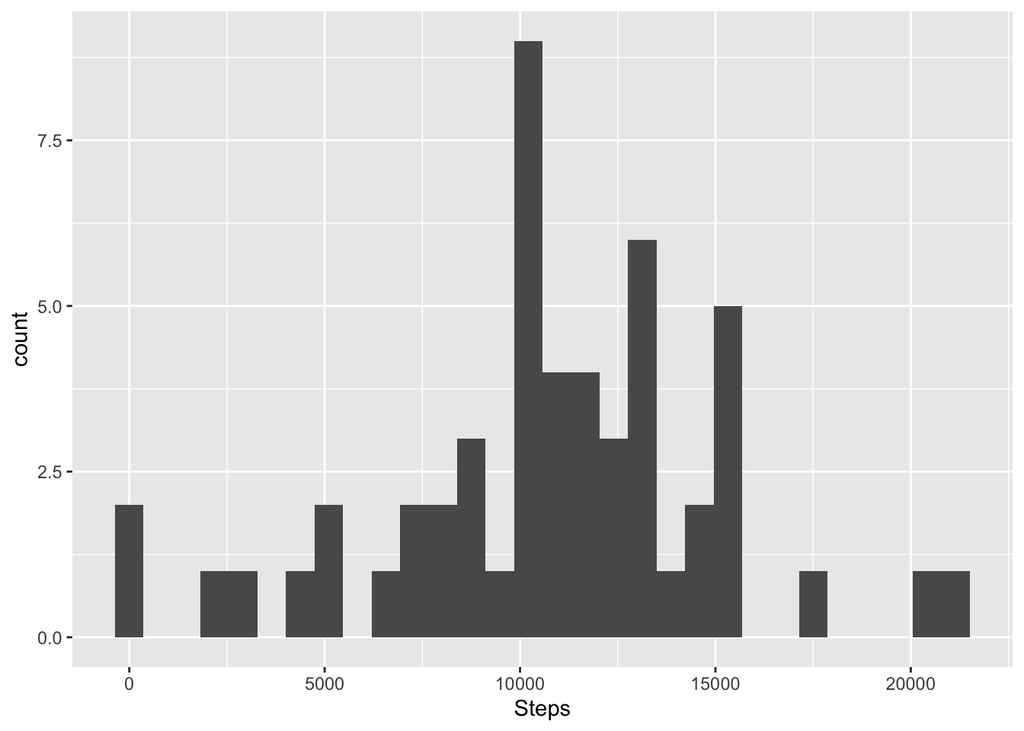

```r
TotalStepsPerDay <- as.data.frame(unique(Data$date))
names(TotalStepsPerDay)<- 'Date'
TotalStepsPerDay$Steps<- sapply(TotalStepsPerDay$Date, function(x){
  day<- subset(Data,date==x )
  sum(day$steps)
})
library(ggplot2)
library(tidyverse)
  ggplot(TotalStepsPerDay, aes(x=Steps)) + geom_histogram()
```

```r
Mean_Median_Data <- as.data.frame(unique(Data$date))
names(Mean_Median_Data)<- 'Date'
Mean_Median_Data$MeanSteps<- sapply(Mean_Median_Data$Date, function(x){
  mean(subset(Data,date==x)$steps, na.rm=T)
  })

Mean_Median_Data$MedianSteps<- sapply(Mean_Median_Data$Date, function(x){
  median(subset(Data,date==x)$steps, na.rm=T)
  })
Mean_Median_Data$MedianStepsNo0<- sapply(Mean_Median_Data$Date, function(x){
  median(subset(Data,date==x& steps!=0)$steps, na.rm=T)
  })
Mean_Median_Data
```

```
##          Date  MeanSteps MedianSteps MedianStepsNo0
## 1  2012-10-01        NaN          NA             NA
## 2  2012-10-02  0.4375000           0           63.0
## 3  2012-10-03 39.4166667           0           61.0
## 4  2012-10-04 42.0694444           0           56.5
## 5  2012-10-05 46.1597222           0           66.0
## 6  2012-10-06 53.5416667           0           67.0
## 7  2012-10-07 38.2465278           0           52.5
## 8  2012-10-08        NaN          NA             NA
## 9  2012-10-09 44.4826389           0           48.0
## 10 2012-10-10 34.3750000           0           56.5
## 11 2012-10-11 35.7777778           0           35.0
## 12 2012-10-12 60.3541667           0           46.0
## 13 2012-10-13 43.1458333           0           45.5
## 14 2012-10-14 52.4236111           0           60.5
```

[output cut: 47 more lines]

### What is the average daily activity pattern?

Creating a table to calculate the mean per interval (excluding any NA values) then plotting the result on a line graph. I have then found the maximum of the mean steps per interval to find the interval that has the greatest number of mean steps, this was 835.

```r
MeanStepsPerDay <- mean(Data$steps,na.rm = T)
MedianStepsPerDay <- median(Data$steps,na.rm = T)

MeanStepsPerDay
```

```
## [1] 37.3826
```

```r
MedianStepsPerDay
```

```
## [1] 0
```

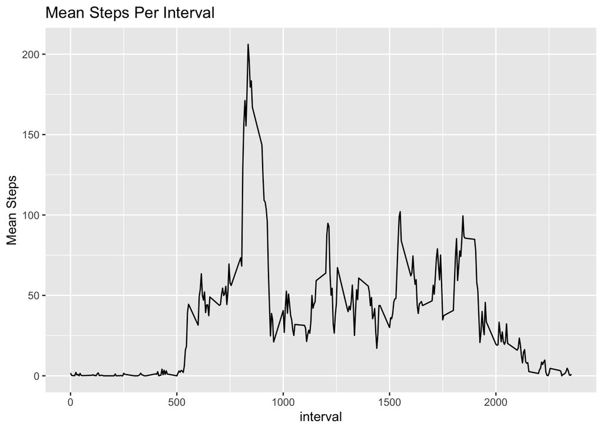

```r
MeanPerInterval<- aggregate(steps~interval, Data, mean)
ggplot(na.omit(MeanPerInterval))+ geom_line(aes(y = steps, x =interval )) + ylab('Mean Steps') +ggtitle('Mean Steps Per Interval')
```

```r
subset(MeanPerInterval, steps== max(MeanPerInterval$steps))
```

```
##     interval    steps
## 104      835 206.1698
```